# 8 Visualization

Figures can help answer three different questions:

- **What patterns should we investigate?** Use plots to explore distributions and relationships, as in Chapter 7.
- **Does an explanation fit the data?** Use diagnostic displays to find patterns that a summary statistic can hide.
- **What should an audience understand?** Choose a display that makes the main comparison clear and gives readers enough context to evaluate it.

The same dataset can produce different impressions when the selected records, denominator, scale, or visual form changes. A figure is therefore part of the analysis, not decoration added after the calculation. The principles here also apply to prediction and model diagnostics in Chapter 9. Examples use NYPD-directed 311 illegal-parking requests from September 6–12, 2026, with maps and a small simulated dataset to illustrate design problems that the request data alone cannot isolate (Munzner, 2014; Wilke, 2019).

When no chart is obvious, work through four questions:

1. What is the observational unit and which records are eligible?
2. What quantity and comparison answer the substantive question?
3. Which visual form preserves the information needed for that comparison?
4. What conclusion might a reader draw, and does the evidence support it?

The code examples demonstrate these decisions. The exercises ask students to apply them to new questions and data sources while preparing for the midterm project. Examples build on course demonstrations by Sonia Lucey (Plotnine), Alejandro Haerter (GeoPandas), and Jack Perkins (Google Maps), and use files distributed with the book.

## 8.1 Purpose

The question determines which information a figure needs to show. For example:

- **Compare numerical levels:** positions on a shared scale help readers judge values more accurately than areas or color intensities (Cleveland & McGill, 1984; Mackinlay, 1986).
- **Compare distributions:** show spread, shape, and tails. Two groups can have the same mean but very different distributions.
- **Compare locations:** plot points when individual recorded locations matter; use polygons when comparing area summaries.

There is no one chart type for every purpose. During exploration, several views may reveal different aspects of the data. A figure for communication should make its main comparison easy to identify and retain the context that qualifies it. First specify the observational unit, measured variable, eligible records, and period from Chapter 5 and Chapter 6. Changing any of these changes the quantity being displayed.

The examples use the screened request table from Chapter 7, but each display has its own eligible set. The hourly and closure-time plots use all screened requests; the point map requires usable coordinates. That difference matters: missing coordinates could be concentrated in a particular borough or problem detail, so the map may not represent every request. The code below loads the shared table with the preparation function, creates time fields needed later, and reports the starting counts. It gives readers a concrete denominator to compare with later maps without repeating the import and filtering code (NYC Open Data, n.d.).

```python
from pathlib import Path

import geopandas as gpd
import matplotlib.pyplot as plt
import numpy as np
import pandas as pd
from matplotlib_inline.backend_inline import set_matplotlib_formats
from IPython.display import display
from plotnine import (
    aes, facet_grid, facet_wrap, geom_line, geom_point, ggplot, labs,
    scale_color_manual, scale_x_continuous, theme, theme_minimal,
)
from scripts.parking_requests import load_parking_requests, load_zcta_context

set_matplotlib_formats("svg")

parking = load_parking_requests()
parking["hour"] = parking["created_at"].dt.hour
parking["day_type"] = np.where(
    parking["created_at"].dt.dayofweek >= 5, "Weekend", "Weekday"
)

pd.Series({
    "requests": len(parking),
    "unique request IDs": parking["request_id"].nunique(),
    "missing coordinates": parking[["latitude", "longitude"]]
        .isna().any(axis=1).sum(),
}).to_frame("count")
```

|  | count |
| --- | --- |
| requests | 13040 |
| unique request IDs | 13040 |
| missing coordinates | 99 |

The compact report establishes the denominator for the chapter’s figures and identifies the requests that cannot appear as points. The hourly and closure-time displays use the full screened table, whereas a point map must exclude rows without usable coordinates. The subset represented by the map could differ systematically if missing locations are concentrated in a borough or problem-detail group; marker transparency does not correct that coverage difference. An area map introduces another eligibility rule when it requires a five-digit ZIP label or a polygon assignment. Each caption should therefore name its eligible records, measured quantity, units, observation period, and any exclusion relevant to interpretation. These facts belong next to the display because the same source archive can produce different plotted populations. The locally held archive and its provenance are documented in Chapter 5; the remaining sections concentrate on how analysis choices become visible in a figure.

## 8.2 Grammar of Graphics

The grammar of graphics provides a language for specifying how data become a figure. Its components describe the choices that connect observations to visible marks:

- **Data.** The data component identifies the observations and variables used by a layer.
- **Aesthetic mappings.** A mapping assigns variables to visual properties such as horizontal position, vertical position, color, or size; a fixed property is set independently of a variable.
- **Geometric marks.** A geom determines the marks used to display the data, such as points, lines, or bars.
- **Statistical transformations.** A statistical transformation summarizes or otherwise transforms observations before the geom draws them.
- **Scales.** A scale translates data values into visual values, such as positions on an axis or colors in a legend.
- **Coordinates.** A coordinate system specifies how mapped positions are arranged in the display, including the spatial frame used by a map.
- **Facets.** Facets repeat a common specification across subsets of the data so that panels can be compared.

This decomposition makes a figure revisable: an analyst can change a mapping, geom, or facet layout without reconstructing the entire graphic. Wilkinson developed the general framework, Wickham formalized a layered implementation in ggplot2, and Plotnine implements that approach in Python (Plotnine Developers, 2026; Wickham, 2010; Wilkinson, 2005).

The first example compares the hours when requests were created on weekdays and weekend days. The study week has five weekdays but only two weekend days, so raw totals would give the weekday group more time to accumulate requests. For borough $b$, day type $d$, and hour $h$, let $n_{bdh}$ be the request count and $D_d$ the number of observed days of that type. The plotted value $n_{bdh}/D_d$ is the average number of requests per observed day in that hour. The code constructs it in three steps:

1. Count requests for each borough, day type, and hour.
2. Add any missing combinations with a count of zero. Without these zeroes, a line would skip hours with no requests.
3. Divide each count by five for weekdays or two for weekend days.

This puts the two day types on a comparable time basis. It does not account for borough population, vehicles, reporting behavior, or an unusual day in this one-week period.

```python
borough_order = ["BRONX", "BROOKLYN", "MANHATTAN", "QUEENS", "STATEN ISLAND"]
hour_index = pd.MultiIndex.from_product(
    [borough_order, ["Weekday", "Weekend"], range(24)],
    names=["borough", "day_type", "hour"],
)
hourly = (
    parking.groupby(["borough", "day_type", "hour"])
    .size()
    .reindex(hour_index, fill_value=0)
    .rename("requests")
    .reset_index()
)
hourly["days_observed"] = hourly["day_type"].map(
    {"Weekday": 5, "Weekend": 2}
)
hourly["requests_per_day"] = hourly["requests"] / hourly["days_observed"]
hourly["borough"] = pd.Categorical(
    hourly["borough"], categories=borough_order, ordered=True
)
```

The Brooklyn figure demonstrates how a layered specification assigns a different role to each visual component. Hour is mapped to horizontal position, the normalized request count to vertical position, and day type to color. The line geom connects adjacent hourly summaries within each day type, while the point geom marks the 24 discrete hours from which those lines are constructed. A connecting line helps readers follow the temporal pattern, but it does not imply that requests were observed continuously between the hourly bins. The manual color scale assigns stable colors to the two categories, and the labeled horizontal breaks make the time scale legible without printing every hour. The code supplies a legend because color is mapped to a variable; changing a constant line color would not create a second group. Brooklyn provides a compact example before the same specification is repeated across boroughs. Readers should compare the timing and level of recorded requests, while retaining the one-week scope of the data (Heer & Bostock, 2010).

```python
brooklyn_hours = hourly.loc[hourly["borough"].eq("BROOKLYN")]
hour_plot = (
    ggplot(brooklyn_hours, aes("hour", "requests_per_day", color="day_type"))
    + geom_line(size=1)
    + geom_point(size=1.5)
    + scale_color_manual(values={"Weekday": "#3366AA", "Weekend": "#CC6677"})
    + scale_x_continuous(breaks=[0, 6, 12, 18, 23])
    + labs(
        x="Hour request was created", y="Requests per observed day",
        color="Day type", title="When Brooklyn requests were created",
    )
    + theme_minimal()
    + theme(figure_size=(6.4, 3.7))
)
display(hour_plot.draw())
```

[figure not shown]

Figure 8.1: Average requests per observed day by hour and day type in Brooklyn, September 6–12, 2026.

Faceting repeats one plot specification across subsets of the data. These two layouts answer related questions:

- **`facet_wrap("borough")`:** each borough gets a panel, and color distinguishes weekdays from weekends. Compare the two time profiles within each borough, then scan across boroughs.
- **`facet_grid("day_type ~ borough")`:** day type defines rows and borough defines columns. The panel position identifies both groups, so color is not needed to distinguish weekdays and weekends.

Both plots use a fixed vertical scale. A height of 20 requests per observed day means the same thing in every panel, though low-count panels can look flatter. Free scales make within-panel shapes easier to see but remove direct comparisons of levels. Choose the scale according to the question and state the choice in the caption (Plotnine Developers, 2026).

```python
borough_facet_plot = (
    ggplot(hourly, aes("hour", "requests_per_day", color="day_type"))
    + geom_line(size=.8)
    + facet_wrap("borough", ncol=3)
    + scale_color_manual(values={"Weekday": "#3366AA", "Weekend": "#CC6677"})
    + scale_x_continuous(breaks=[0, 6, 12, 18, 23])
    + labs(x="Hour request was created", y="Requests per observed day",
           color="Day type")
    + theme_minimal()
    + theme(figure_size=(6.4, 4.4))
)
display(borough_facet_plot.draw())
```

[figure not shown]

Figure 8.2: Average hourly request counts per observed day, with a separate panel for each borough.

```python
day_borough_facet_plot = (
    ggplot(hourly, aes("hour", "requests_per_day"))
    + geom_line(color="#3366AA", size=.8)
    + facet_grid("day_type ~ borough")
    + scale_x_continuous(breaks=[0, 12, 23])
    + labs(x="Hour request was created", y="Requests per observed day")
    + theme_minimal()
    + theme(figure_size=(6.4, 4.4))
)
display(day_borough_facet_plot.draw())
```

[figure not shown]

Figure 8.3: The same hourly summaries arranged by day type (rows) and borough (columns), with fixed scales.

Use the wrap when readers should compare weekday and weekend patterns inside each borough. Use the grid when separating the day types makes the panels easier to scan. Neither layout solves a limitation in the data: Labor Day falls on the Monday labeled as a weekday. The weekday line averages five calendar days, including a holiday, so it may not represent an ordinary workday. For a commuting question, the analysis would need a holiday flag, more weeks of data, or a narrower interpretation. A valid facet design can still compare groups that do not match the intended question.

## 8.3 Comparisons

Choose a visual form that preserves the part of the data needed for the question:

- **Counts:** bars should begin at zero because their lengths encode size.
- **Close estimates:** aligned dots on a shared scale make small differences easier to compare.
- **Spread or skewness:** show a distribution or an explicit measure of variation; a mean bar can hide a long tail (Cleveland & McGill, 1984; Weissgerber et al., 2015).
- **Change over an ordered variable:** lines can show a sequence such as time. Connecting unordered categories can imply a relationship that is not present.
- **Groups and magnitude:** hue can distinguish categories, while ordered lightness can show magnitude. Add position or labels when color alone may be difficult to distinguish (Crameri et al., 2020; Harrower & Brewer, 2003).

The closure-time plot compares the three details with the most requests in the selected week. Each mark has a specific meaning:

- The **dot** is the median recorded closure time.
- The **line** extends from the first quartile to the third quartile, covering the middle half of observed closure times.
- The line is **not a confidence interval**. It describes variation among records in this extract, not uncertainty about a population median or a difference between groups (Correll & Gleicher, 2014).

This display makes group centers and middle spreads easy to compare. Use the empirical cumulative distribution in Chapter 7 when distribution shape or the extreme tail is the main question.

```python
top_details = parking["problem_detail"].value_counts().head(3).index
top = parking.loc[parking["problem_detail"].isin(top_details)]
detail_summary = (
    top.groupby("problem_detail")["closure_hours"]
    .quantile([.25, .5, .75])
    .unstack()
    .rename(columns={.25: "q25", .5: "median", .75: "q75"})
    .sort_values("median")
)

fig, ax = plt.subplots(figsize=(6.4, 3.4))
positions = range(len(detail_summary))
ax.errorbar(
    detail_summary["median"], positions,
    xerr=[detail_summary["median"] - detail_summary["q25"],
          detail_summary["q75"] - detail_summary["median"]],
    fmt="o", color="#3366AA", ecolor="#666666", capsize=3,
)
ax.set_yticks(list(positions), detail_summary.index)
ax.set(xlabel="Recorded closure time (hours)",
       title="Medians and middle-half ranges by problem detail")
ax.grid(axis="x", color="0.9")
fig.tight_layout()
plt.show()
```

[figure not shown]

Figure 8.4: Median and middle-half range of recorded closure times for the three most reported illegal-parking details, September 6–12, 2026.

Read the figure in this order:

1. Follow the common horizontal scale to compare the median dots.
2. Compare each line’s length to see how widely the middle half of closure times varies within that group.
3. Notice that the intervals overlap. The median ordering does not mean that individual requests in one group always closed sooner or later than those in another.

The plot leaves out group counts and extreme closure times; the table and cumulative distributions in Chapter 7 retain those details. If the audience needs to see delayed closures, use an upper-tail summary or cumulative plot. This is a descriptive comparison. Location, reporting time, and agency practices may differ among groups, so the visual gaps do not show an effect of the problem-detail label.

## 8.4 Common Mistakes

Misleading figures can enter at several stages:

- **Selection:** omitted records change the population shown.
- **Aggregation:** a summary can conceal variation within groups.
- **Encoding:** a scale or mark can exaggerate small differences.
- **Interpretation:** a title can turn a description into an unsupported causal or citywide claim.

Wainer cataloged recurring ways to obscure data. Later studies examined how visual distortions affect readers and classified misleading figures in published work (Lo et al., 2022; Pandey et al., 2015; Tufte, 2001; Wainer, 1984). Reviewing only labels or colors will miss problems in record selection, denominators, or claims. Ask what conclusion a reader is likely to draw, then check whether the selected records and displayed quantity support it. Table 8.1 summarizes common mistakes, shows a deliberately poor example of each, and offers a repair check. The plots use the illegal-parking data or small simulated examples; their captions name the defect so the misleading design is not mistaken for a recommended one.

Table 8.1: Common visualization mistakes, their misleading examples, and checks for revision.

| Mistake and likely false inference | Bad-plot example | Check or repair | References |
| --- | --- | --- | --- |
| Records without usable coordinates are dropped; the plot appears to include all requests. | Figure 8.5 | Report the excluded count and label the figure as geocoded records, or use a field that supports the full eligible set. | (Lo et al., 2022; Tufte, 2001) |
| A bar axis starts above zero; small differences appear large in length. | Figure 8.7 | Restore zero for a length encoding, or use aligned points when a restricted range is justified. | (Correll et al., 2020) |
| Panels use different scales without a clear cue; similar heights appear comparable. | Figure 8.6 | Use fixed scales for comparisons of level, or state prominently that each panel has its own scale. | (Tufte, 2001; Wainer, 1984) |
| A mean or median appears alone; groups appear to have little internal variation. | Figure 8.8 | Add a distribution, observations, or a defined interval suited to the sample size. | (Correll & Gleicher, 2014; Weissgerber et al., 2015) |
| Bubble area exaggerates a value; larger circles look disproportionately larger. | Figure 8.9 | Encode magnitude with aligned positions or lengths, or scale circle area rather than radius. | (Cleveland & McGill, 1984) |
| A rainbow palette is used for an ordered measure; color bands suggest unsupported thresholds. | Figure 8.12 | Choose an ordered, perceptually consistent palette. | (Crameri et al., 2020; Harrower & Brewer, 2003) |
| An area map shows request counts; darker areas appear to have greater illegal-parking risk. | Figure 8.13 | Examine a suitable denominator and retain the count map for context. | (Openshaw, 1984; Robinson, 1950) |
| A title claims a cause or citywide trend; a one-week association appears to establish that claim. | Figure 8.10 | State the observation period and measured quantity; separate description from explanation. | (Heer & Bostock, 2010; Tufte, 2001) |

The first example drops requests without usable coordinates but gives the remaining counts a title that implies full coverage. This selection can change borough comparisons if missing locations are not distributed evenly. The repair should either use all eligible borough records or state that the figure summarizes geocoded requests and report how many records were excluded.

```python
geocoded_by_borough = (
    parking.dropna(subset=["latitude", "longitude"])
    .groupby("borough")
    .size()
    .reindex(borough_order, fill_value=0)
)
fig, ax = plt.subplots(figsize=(6.4, 3.8))
ax.bar(geocoded_by_borough.index, geocoded_by_borough.values,
       color="#4477AA")
ax.set(title="All illegal-parking requests by borough",
       ylabel="Recorded requests")
ax.tick_params(axis="x", rotation=25)
fig.tight_layout()
plt.show()
```

[figure not shown]

Figure 8.5: A misleading title implies that all requests are counted, although the plot excludes records without usable coordinates.

The faceted example uses borough-specific vertical scales without explaining that they differ. This makes the local peaks appear similar even though the request levels are not. Fixed scales allow level comparisons; free scales can help readers compare within-borough shape, but the caption and axes must make that purpose clear.

```python
mistake_facet_plot = (
    ggplot(hourly, aes("hour", "requests_per_day", color="day_type"))
    + geom_line(size=.8)
    + facet_wrap("borough", ncol=3, scales="free_y")
    + scale_color_manual(values={"Weekday": "#3366AA", "Weekend": "#CC6677"})
    + scale_x_continuous(breaks=[0, 12, 23])
    + labs(x="Hour request was created", y="Requests per observed day",
           color="Day type", title="Similar hourly request levels by borough")
    + theme_minimal()
    + theme(figure_size=(6.4, 4.4))
)
display(mistake_facet_plot.draw())
```

[figure not shown]

Figure 8.6: A misleading faceted plot: each borough has its own vertical range, so similar panel heights do not indicate similar request levels.

Baseline decisions should follow the visual quantity the reader is asked to compare. A bar represents a numerical value through its length from a common origin; when the origin is cut off, the apparent ratios between bar lengths no longer represent ratios between values. A line or dot plot primarily uses position, so a restricted range can help expose a small change if the axis limits are conspicuous and the plot does not invite an unwarranted comparison of physical lengths. Truncation can nevertheless alter perceived effect size across chart types, even when a visual cue signals the change (Correll et al., 2020). The paired figure holds the three median closure times fixed and changes only the horizontal limits. The left panel makes the differences occupy a larger fraction of the available bar length; the right panel restores the zero baseline required for a literal length comparison. Both panels omit the within-group spread shown in Figure 8.4, which is a separate loss of information.

```python
medians = detail_summary["median"]
fig, axes = plt.subplots(1, 2, figsize=(6.4, 3.4), sharey=True)
for ax in axes:
    ax.barh(medians.index, medians, color="#3366AA")
    ax.set_xlabel("Median closure time (hours)")
axes[0].set_xlim(medians.min() * .85, medians.max() * 1.08)
axes[0].set_title("Truncated baseline")
axes[1].set_xlim(0, medians.max() * 1.08)
axes[1].set_title("Zero baseline")
fig.tight_layout()
plt.show()
```

[figure not shown]

Figure 8.7: Identical median closure times with a truncated baseline (left) and a zero baseline (right). The left bars exaggerate differences in length.

Summary statistics can conceal differences even when the axes and scales are technically correct. In the following constructed example, both groups have a mean of two units. Group A contains three zeroes and two fives, whereas all five observations in group B equal two. The equal-height bars correctly display the two means, but they cannot communicate the different concentration and range of the observations. The point display retains the five individual values in each group and makes that difference visible. This example isolates information loss due to aggregation; it does not show that individual points are always the appropriate marks. Thousands of service requests would create severe overplotting, for which a histogram, empirical cumulative distribution, density display, or selected quantiles could better represent variation. The choice depends on whether the question concerns center, spread, tail behavior, or individual cases, and on how many observations can be displayed legibly (Correll & Gleicher, 2014; Weissgerber et al., 2015).

```python
simulated = {"A": np.array([0, 0, 0, 5, 5]),
             "B": np.array([2, 2, 2, 2, 2])}
fig, axes = plt.subplots(1, 2, figsize=(6.4, 3.4))
axes[0].bar(list(simulated), [values.mean() for values in simulated.values()],
            color="#3366AA")
axes[0].set(title="Means only", ylabel="Observed value", ylim=(0, 6))
for position, (name, values) in enumerate(simulated.items()):
    offsets = np.linspace(-.13, .13, len(values))
    axes[1].scatter(position + offsets, values, color="#3366AA", s=35)
axes[1].set(xticks=[0, 1], xticklabels=list(simulated),
            title="Individual values", ylabel="Observed value", ylim=(0, 6))
fig.tight_layout()
plt.show()
```

[figure not shown]

Figure 8.8: Two simulated groups have the same mean but different observed distributions.

The next plot uses circle radius, rather than circle area, to encode median closure time. Because the area of a circle grows with the square of its radius, this choice exaggerates differences between the three problem details. A position or length encoding supports more reliable comparisons.

```python
bubble_values = detail_summary["median"]
fig, ax = plt.subplots(figsize=(6.4, 3.4))
x_positions = np.arange(len(bubble_values))
ax.scatter(x_positions, np.zeros(len(bubble_values)),
           s=(bubble_values.to_numpy() * 30) ** 2,
           color="#4477AA", alpha=.65)
ax.set(xticks=x_positions, xticklabels=bubble_values.index,
       yticks=[], title="Median closure time shown by bubble radius")
for spine in ["left", "right", "top"]:
    ax.spines[spine].set_visible(False)
fig.tight_layout()
plt.show()
```

[figure not shown]

Figure 8.9: A misleading bubble plot: circle radius is proportional to median closure time, so circle area exaggerates the differences.

Color and annotation should be evaluated by the comparisons they enable. Distinct hues can identify unordered categories; progressively ordered lightness can represent increasing magnitude; and a diverging scale is appropriate when a defined reference, such as zero change, separates two directions. An uneven gradient can create apparent thresholds where the data are continuous, while a distinction conveyed only by red and green can be inaccessible to some readers (Crameri et al., 2020; Harrower & Brewer, 2003). Decoration is not categorically harmful: experiments with embellished figures complicate a blanket prohibition (Bateman et al., 2010). The appropriate test is whether an element helps readers locate or compare evidence without implying an unsupported result. Every plot should also be reviewed as a claim. Its title should match the measured quantity; its axes and legend should state units; and its caption should identify the source, observation period, aggregation, and exclusions. When a figure is revised, the analyst should inspect the source records again to confirm that the repaired display still represents the intended population and denominator.

The final example gives one week of request counts a title that claims a citywide trend. The bars describe recorded requests in this extract; they do not establish a long-term increase in illegal parking across New York City. The repaired title and caption should name the observation period and avoid extending the conclusion beyond the available records.

```python
daily_counts = parking.groupby(parking["created_at"].dt.normalize()).size()
fig, ax = plt.subplots(figsize=(6.4, 3.6))
ax.bar(daily_counts.index, daily_counts.values, color="#4477AA")
ax.set(title="Illegal parking is increasing across New York City",
       xlabel="Date in the one-week extract", ylabel="Recorded requests")
fig.autofmt_xdate()
fig.tight_layout()
plt.show()
```

[figure not shown]

Figure 8.10: A misleading title turns one week of recorded request counts into an unsupported citywide trend claim.

## 8.5 Maps

Maps require a choice of geographic unit as well as a visual form. This chapter uses request coordinates and polygons for the city’s 221 ZIP Code Tabulation Areas (ZCTAs) (NYC Open Data, 2026c):

- A **point map** shows where requests were recorded. Points are approximate, may overlap, and may be missing for some requests.
- A **choropleth** colors each area according to an aggregate value. It makes area summaries comparable but hides variation within each polygon.

Choose the map according to the question: where were reports recorded, how many matched an area, or how did an area summary vary? Population estimates from Section 6.4 can provide a denominator, but the resulting rate is requests per resident during the stated period. The map’s title, legend, and caption should name that quantity; request rates are not verified illegal-parking prevalence.

The map code must also identify how coordinates are represented. The request table stores longitude and latitude, so its points begin in EPSG:4326. The local ZCTA boundary file is derived from the official NYC source; its provenance note records the download and simplification. GeoPandas can transform between coordinate systems, but metadata alone does not prove that a point is located correctly.

The static city maps use New York State Plane coordinates (EPSG:2263). This projected system is useful for displaying the city and for calculations in linear units. Longitude and latitude are angular coordinates: a degree of longitude does not represent the same ground distance everywhere. A projection changes how coordinates are represented; it cannot fix a wrong address, approximate geocode, or missing location (GeoPandas Developers, 2026b).

```python
zcta_polygons = gpd.read_file(Path("data") / "nyc_zcta_boundaries.geojson")
zcta_context = load_zcta_context()
with_coordinates = parking.dropna(subset=["latitude", "longitude"]).copy()
request_points = gpd.GeoDataFrame(
    with_coordinates,
    geometry=gpd.points_from_xy(
        with_coordinates["longitude"], with_coordinates["latitude"]
    ),
    crs="EPSG:4326",
)
pd.Series({
    "requests in scope": len(parking),
    "requests with coordinates": len(request_points),
    "ZCTA polygons": len(zcta_polygons),
}).to_frame("count")
```

|  | count |
| --- | --- |
| requests in scope | 13040 |
| requests with coordinates | 12941 |
| ZCTA polygons | 221 |

A point map with many observations needs a display rule that accounts for overlap. Several requests can share a geocoded address, and opaque markers would cover earlier marks at the same or nearby positions. The following figure therefore uses a reproducible random sample of 2,000 geocoded requests and draws small, transparent points over ZCTA outlines. Sampling reduces the number of overlapping marks while preserving, in expectation, the distribution of locations among geocoded records. It also makes the plot unsuitable for reading exact counts at a location: the absence of a sampled point does not imply the absence of requests. Transparency helps show accumulation, but apparent density still depends on point size, opacity, and map scale. The polygon outlines provide orientation rather than an area-level measurement. A density surface would introduce further choices, especially a smoothing bandwidth and treatment of boundaries; those choices would need to be reported before the surface could support a quantitative comparison.

```python
sample_points = request_points.sample(n=2000, random_state=2026)
fig, ax = plt.subplots(figsize=(6.2, 6.2))
zcta_polygons.to_crs("EPSG:2263").boundary.plot(
    ax=ax, color="#999999", linewidth=.3
)
sample_points.to_crs("EPSG:2263").plot(
    ax=ax, color="#225588", markersize=3, alpha=.3
)
ax.set_axis_off()
ax.set_title("Recorded request locations and ZCTA boundaries")
fig.tight_layout()
plt.show()
```

[figure not shown]

Figure 8.11: A reproducible sample of 2,000 geocoded illegal-parking requests over NYC ZCTA boundaries, September 6–12, 2026.

An area map requires an assignment rule that maps each request to a named polygon or reports why it remains unassigned. Section 6.4 used equality of the provider’s five-digit postal ZIP label and a Census ZCTA code; it also explained why equal labels do not imply identical geographies (U.S. Census Bureau, 2023). Coordinates permit an alternative point-in-polygon assignment. That operation answers a different question, because it uses the recorded point rather than the provider’s postal label. It requires valid coordinates, a selected polygon file, and a spatial predicate. Under `within`, a point exactly on a boundary does not belong to either adjoining polygon, while overlaps can assign one request to several polygons. An imprecise geocode or simplified boundary can also change a near-edge match. Before shading a map, the analyst should count one-to-one, unmatched, and multiple assignments and decide which rule corresponds to the geographic target. The diagnostic below makes those outcomes visible for the supplied ZCTA polygons (NYC Open Data, 2026c).

```python
point_zcta = gpd.sjoin(
    request_points[["request_id", "incident_zip", "geometry"]],
    zcta_polygons[["zcta", "geometry"]],
    how="left", predicate="within",
)
match_count = point_zcta.groupby(level=0)["zcta"].count()
pd.Series({
    "one polygon": match_count.eq(1).sum(),
    "no polygon": match_count.eq(0).sum(),
    "more than one polygon": match_count.gt(1).sum(),
}).to_frame("geocoded requests")
```

|  | geocoded requests |
| --- | --- |
| one polygon | 12892 |
| no polygon | 21 |
| more than one polygon | 28 |

The spatial diagnostic shows that 21 geocoded requests have no polygon match and 28 have more than one match in the compact boundary file. These counts establish that the join cannot be substituted silently for the provider’s ZIP field. A boundary point may fail the `within` predicate; overlapping polygons may produce multiple rows for one request; and boundary simplification can change a near-edge result. Each mechanism requires a different response. For a precise point-to-area study, the analyst should inspect the ambiguous records against the original boundaries, state a tie-breaking rule if one is justified, and report the remaining exclusions. The maps below instead retain the ZIP-label match introduced in Section 6.4, which keeps their area summaries comparable to the earlier data-preparation example. The point-in-polygon results remain a diagnostic of geographic disagreement rather than an unexamined source of replacement labels.

The paired choropleths separate the effect of a numerator from the effect of a denominator. For ZCTA $z$, let $N_z$ be the number of selected requests whose valid five-digit provider ZIP label matches its code, and let $P_z$ be its 2020–2024 American Community Survey population estimate. The first map shows $N_z$; the second shows $10{,}000N_z/P_z$ when $P_z>0$. Its unit is requests per 10,000 estimated residents during the selected week. The formula does not measure the probability that a resident experiences illegal parking, because the numerator consists of requests rather than verified events and the population is not the number of parking opportunities. It also combines 2026 requests with an earlier population estimate. Twenty-seven ZCTAs have a zero population estimate; their rates are undefined and appear in gray rather than as zero. A polygon with no matched ZIP-label requests can still contain geocoded requests assigned another label. Both maps use ordered color, but separate legends identify their different quantities and units (Crameri et al., 2020; Harrower & Brewer, 2003).

```python
valid_zip = parking["incident_zip"].str.fullmatch(r"\d{5}", na=False)
area_counts = (
    parking.loc[valid_zip]
    .groupby("incident_zip")
    .size()
    .rename("requests")
    .reset_index()
    .rename(columns={"incident_zip": "zcta"})
)
area_map = (
    zcta_polygons
    .merge(zcta_context[["zcta", "population"]],
           on="zcta", validate="one_to_one")
    .merge(area_counts, on="zcta", how="left", validate="one_to_one")
)
area_map["requests"] = area_map["requests"].fillna(0).astype(int)
area_map["requests_per_10k"] = np.where(
    area_map["population"].gt(0),
    area_map["requests"] / area_map["population"] * 10_000,
    np.nan,
)
```

The next two plots illustrate the map-specific mistakes in Table 8.1. The first pairs a continuous rate with a rainbow palette, which can suggest abrupt boundaries that are not present in the data. The second presents counts as risk even though ZCTAs differ in population and other exposure. The count map can describe service workload, but it does not by itself identify where illegal parking is more likely.

```python
projected_map = area_map.to_crs("EPSG:2263")
fig, ax = plt.subplots(figsize=(6.2, 6.2))
projected_map.plot(column="requests_per_10k", cmap="rainbow", legend=True,
                   ax=ax, legend_kwds={"shrink": 0.6},
                   missing_kwds={"color": "#bdbdbd"})
ax.set_title("Requests per 10,000 residents (rainbow scale)")
ax.set_axis_off()
fig.tight_layout()
plt.show()
```

[figure not shown]

Figure 8.12: A misleading choropleth: the rainbow palette introduces strong hue boundaries into a continuous request rate.

```python
fig, ax = plt.subplots(figsize=(6.2, 6.2))
projected_map.plot(column="requests", cmap="OrRd", legend=True, ax=ax,
                   legend_kwds={"shrink": 0.6})
ax.set_title("Illegal-parking risk by ZCTA")
ax.set_axis_off()
fig.tight_layout()
plt.show()
```

[figure not shown]

Figure 8.13: A misleading choropleth: raw request counts are titled as illegal-parking risk, although areas differ in population and exposure.

```python
projected_map = area_map.to_crs("EPSG:2263")
fig, axes = plt.subplots(1, 2, figsize=(6.4, 3.5))
for ax, variable, title in [
    (axes[0], "requests", "Recorded requests"),
    (axes[1], "requests_per_10k", "Requests per 10,000 residents"),
]:
    projected_map.plot(
        column=variable, ax=ax, cmap="viridis", legend=True,
        legend_kwds={"shrink": .6}, edgecolor="white", linewidth=.15,
        missing_kwds={"color": "#dddddd", "label": "Rate unavailable"},
    )
    ax.set_title(title)
    ax.set_axis_off()
fig.tight_layout()
plt.show()
```

[figure not shown]

Figure 8.14: Illegal-parking request counts (left) and requests per 10,000 estimated residents (right) by matched NYC ZCTA label, September 6–12, 2026. Gray areas have undefined rates because their population estimate is zero.

Differences between the count and rate maps require substantive interpretation before they are treated as evidence of geographic risk. Residential population need not be proportional to the number of drivers, visitors, curb spaces, or people likely to report a problem. A commercial area with few residents can therefore have a high per-resident request rate without having an unusually high number of requests. Map color also depends on the chosen boundaries: combining ZCTAs into boroughs can conceal local variation, while a different grouping of neighborhoods can change the apparent association between location and requests (Armstrong & Wattenberg, 2014; Openshaw, 1984). Even a stable area-level pattern does not establish the behavior or exposure of individual residents (Robinson, 1950). A defensible map should therefore state the numerator, denominator, time period, assignment rule, and treatment of unmatched records. The analyst should also ask whether the geographic arrangement answers a question that a sorted table or dot plot could not answer as clearly.

## 8.6 Interactive Maps

An interactive map helps when a reader needs to find an area, inspect an exact value, or move between a city view and a street view. It does not fix a poor denominator, uncertain geocode, or unsupported conclusion. The GeoPandas `.explore()` method uses Folium and Leaflet to map the same ZCTA summaries as the static figures:

- Polygon color gives requests per 10,000 estimated residents.
- The tooltip gives the ZCTA, request count, population estimate, and rate.
- CARTO’s Positron tiles provide a basemap when a key is available; otherwise the example uses OpenStreetMap (CARTO, 2026; GeoPandas Developers, 2026a).

Showing the count and population beside the rate helps a reader understand an unusually high value. Keep the static map as a stable comparison and for readers who cannot use the interactive version. CARTO keys are supplied via the `CARTO_BASEMAP_API_KEY` environment variable or a local `cartoBaseAPIKey.txt` file. Because the key appears in browser tile requests, restrict it to the intended site or local preview, keep the file out of Git, and do not publish an HTML page containing an unrestricted key (CARTO, 2026).

```python
import os
from pathlib import Path
from urllib.parse import quote

carto_key = os.environ.get("CARTO_BASEMAP_API_KEY")
if carto_key is None and Path("cartoBaseAPIKey.txt").exists():
    carto_key = Path("cartoBaseAPIKey.txt").read_text().strip()

tile_options = {"tiles": "OpenStreetMap"}
if carto_key:
    tile_options = {
        "tiles": (
            "https://basemaps.cartocdn.com/rastertiles/light_all/"
            f"{{z}}/{{x}}/{{y}}.png?key={quote(carto_key, safe='')}"
        ),
        "attr": "© OpenStreetMap contributors, © CARTO",
    }

interactive_map = area_map.loc[area_map["population"].gt(0)].explore(
    column="requests_per_10k",
    cmap="viridis",
    tooltip=["zcta", "requests", "population", "requests_per_10k"],
    legend=True,
    **tile_options,
)
interactive_map
```

Make this Notebook Trusted to load map: File -> Trust Notebook

[interactive chart not shown]

Figure 8.15: Interactive ZCTA map of recorded requests per 10,000 estimated residents. Hover to inspect the count and denominator.

The map uses two levels of information:

- **Overview:** color lets the reader compare rates across areas.
- **On demand:** a tooltip gives the exact numerator and denominator behind a selected rate.

Adding every source field to the tooltip would make inspection harder rather than clearer. The interactive map omits 27 areas with zero estimated population because their rates are undefined; the static map marks them in gray. State this difference when showing the maps together. Online tiles can fail, and hover controls can be difficult with a keyboard or touch device. Keep a static figure, concise text description, and accessible table of key values available as alternatives. Ask the same questions as for any plot: which records appear, what is encoded, and what comparison does it support?

Google Maps can provide an alternative basemap for the same ZCTA choropleth. The Maps JavaScript API data layer accepts GeoJSON polygons and supports feature-based styling and click events. The example below transfers the already prepared `area_map` to GeoJSON, styles ZCTAs by the same requests-per-resident measure, and opens a detail window when a reader selects a polygon (Google for Developers, 2026a). It uses quantile breaks calculated from the displayed areas, so the legend reports the class boundaries used by this dataset; its colors therefore do not match the continuous Folium scale one for one. The Folium version remains the default and uses OpenStreetMap if a CARTO key is unavailable.

The Google version runs only when an API key is supplied through the `GOOGLE_MAPS_API_KEY` environment variable. The key must be enabled for the Maps JavaScript API, restricted to that API and to the site or local server that will display the map, and associated with billing. The generated HTML contains the browser key and should stay local; do not commit it or publish it with the book (Google for Developers, 2026c, 2026b).

```python
import json
import os
from html import escape
from pathlib import Path

google_geojson = json.loads(
    area_map.to_crs("EPSG:4326").to_json(drop_id=True)
)
google_geojson_json = json.dumps(
    google_geojson, separators=(",", ":"), allow_nan=False
).replace("</", "<\\/")
rate_breaks = np.unique(
    area_map["requests_per_10k"].dropna().quantile([0.2, 0.4, 0.6, 0.8])
).tolist()
colors = ["#ffffcc", "#a1dab4", "#41b6c4", "#2c7fb8", "#253494"]
colors = colors[:len(rate_breaks) + 1]
rate_labels = [
    f"≤ {rate_breaks[0]:.2f}",
    *[
        f"{lower:.2f}–{upper:.2f}"
        for lower, upper in zip(rate_breaks[:-1], rate_breaks[1:])
    ],
    f"> {rate_breaks[-1]:.2f}",
]
api_key = escape(os.environ["GOOGLE_MAPS_API_KEY"], quote=True)
google_map_html = f"""<!doctype html>
<html lang="en">
<head>
  <meta charset="utf-8">
  <meta name="viewport" content="width=device-width, initial-scale=1">
  <title>Illegal-parking requests by ZCTA</title>
  <style>
    #map {{ height: 90vh; width: 100%; }}
    #legend {{ background: white; padding: 10px; margin: 10px;
              font: 14px sans-serif; }}
    .swatch {{ display: inline-block; width: 12px; height: 12px;
               margin-right: 6px; }}
  </style>
</head>
<body>
  <div id="map" role="application"
       aria-label="Interactive map of NYC ZCTA request rates"></div>
  <script>
    const zctaData = {google_geojson_json};
    const rateBreaks = {json.dumps(rate_breaks)};
    const colors = {json.dumps(colors)};
    const rateLabels = {json.dumps(rate_labels)};

    async function initMap() {{
      const {{ Map, InfoWindow }} = await google.maps.importLibrary("maps");
      const map = new Map(document.getElementById("map"), {{
        center: {{ lat: 40.7128, lng: -74.0060 }},
        zoom: 10,
        mapTypeId: "roadmap",
      }});
      const infoWindow = new InfoWindow();
      map.data.addGeoJson(zctaData);
      map.data.setStyle((feature) => {{
        const rate = feature.getProperty("requests_per_10k");
        const classIndex = rate == null
          ? -1
          : rateBreaks.findIndex((upper) => Number(rate) <= upper);
        const fillColor = classIndex < 0
          ? (rate == null ? "#bdbdbd" : colors[colors.length - 1])
          : colors[classIndex];
        return {{
          fillColor: fillColor,
          fillOpacity: 0.7,
          strokeColor: "#ffffff",
          strokeWeight: 1,
        }};
      }});
      map.data.addListener("click", (event) => {{
        const feature = event.feature;
        const rate = feature.getProperty("requests_per_10k");
        const rateText = rate == null
          ? "Undefined: zero estimated population"
          : `${{Number(rate).toFixed(2)}} requests per 10,000 residents`;
        const content = document.createElement("div");
        content.textContent =
          `ZCTA ${{feature.getProperty("zcta")}} | ` +
          `${{feature.getProperty("requests")}} requests | ` +
          `${{feature.getProperty("population")}} residents | ${{rateText}}`;
        infoWindow.setContent(content);
        infoWindow.setPosition(event.latLng);
        infoWindow.open({{ map }});
      }});

      const legend = document.createElement("div");
      legend.id = "legend";
      legend.innerHTML = rateLabels.map((label, index) =>
        `<div><span class="swatch" style="background:${{colors[index]}}"></span>${{label}}</div>`
      ).join("") +
        '<div><span class="swatch" style="background:#bdbdbd"></span>Rate undefined</div>';
      map.controls[google.maps.ControlPosition.RIGHT_BOTTOM].push(legend);
    }}

    window.initMap = initMap;
  </script>
  <script async
    src="https://maps.googleapis.com/maps/api/js?key={api_key}&callback=initMap&v=weekly">
  </script>
</body>
</html>
"""
Path("parking_requests_google_zcta.html").write_text(
    google_map_html, encoding="utf-8"
)
print("Wrote parking_requests_google_zcta.html")
```

The choice between interactive tools should follow the geographic question and the intended reader action. The GeoPandas–Folium–Leaflet route uses the local ZCTA geometries and runs in the book environment; it supports inspection of the area summaries already constructed. A Google map may be appropriate when the question requires a familiar street basemap or a particular Google service, but the optional example requires key management and produces a separate HTML page. Neither tool decides whether a point should be assigned to an area, which distance measure is substantively relevant, or whether a route is a valid proxy for travel time. For example, straight-line distance from a complaint location to a police precinct is different from network distance and does not include dispatch procedures. A project should therefore define the reader’s task, geographic operation, and units before selecting the interface. It should also account for accessibility, reproducibility, and any information sent to an external map service.

## 8.7 Animate Change

Animation extends a static display by changing one part of the figure across frames. Matplotlib’s `FuncAnimation` repeatedly calls an update function, which changes the marks or data shown for the current frame. A useful animation keeps scales and spatial extents fixed, labels the frame in plain language, and changes only what the question requires. Animation can expose timing or accumulation that is difficult to see in a static figure, but rapid movement can also make comparisons harder. A static summary should remain available for readers who need to compare values across the full period. The examples use the week of illegal-parking requests to animate a borough count and the spatial distribution of recorded locations (Matplotlib Developers, 2026).

The first animation shows cumulative request counts by borough at the end of each day. Each frame adds a day of observations, so the bar lengths show how the total grows over the week. A fixed horizontal scale keeps lengths comparable from frame to frame. The animation describes request volume in this extract; it does not measure illegal-parking prevalence or borough performance.

```python
import base64
import tempfile

from IPython.display import HTML
from matplotlib.animation import FuncAnimation

def display_gif(animation, *, alt_text, caption):
    with tempfile.NamedTemporaryFile(suffix=".gif") as gif_file:
        animation.save(gif_file.name, writer="pillow", fps=1, dpi=90)
        encoded_gif = base64.b64encode(
            Path(gif_file.name).read_bytes()
        ).decode("ascii")
        return HTML(
            f'<figure><img src="data:…" '
            'style="display:block;max-width:100%;height:auto;" '
            f'alt="{alt_text}"><figcaption>{caption}</figcaption></figure>'
        )

daily_borough_counts = (
    parking.assign(date=parking["created_at"].dt.normalize())
    .groupby(["date", "borough"])
    .size()
    .unstack(fill_value=0)
    .reindex(
        index=pd.date_range(
            parking["created_at"].min().normalize(),
            parking["created_at"].max().normalize(),
            freq="D",
        ),
        columns=borough_order,
        fill_value=0,
    )
    .sort_index()
    .cumsum()
)
```

The update function redraws the horizontal bars for the date associated with each frame. The animation is saved as a GIF with Matplotlib’s Pillow writer; the file is created temporarily during rendering, so the figure does not add a generated binary to the repository. The `FuncAnimation` object remains assigned to `count_animation` while the GIF is written, which prevents it from being discarded before all frames are rendered.

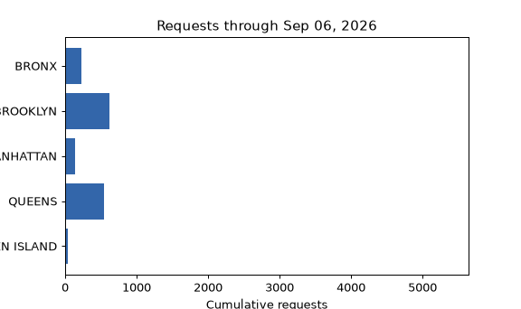

Cumulative number of illegal-parking requests recorded in each borough by date, September 6–12, 2026.

```python
fig, ax = plt.subplots(figsize=(6.4, 3.8))
count_limit = daily_borough_counts.to_numpy().max() * 1.1

def update_count(frame):
    ax.clear()
    counts = daily_borough_counts.iloc[frame]
    ax.barh(counts.index, counts.values, color="#3366AA")
    ax.set_xlim(0, count_limit)
    ax.set_xlabel("Cumulative requests")
    ax.set_title(
        f"Requests through {daily_borough_counts.index[frame]:%b %d, %Y}"
    )
    ax.invert_yaxis()

count_animation = FuncAnimation(
    fig, update_count, frames=range(len(daily_borough_counts)),
    interval=700, repeat=False,
)
count_gif = display_gif(
    count_animation,
    alt_text="An animated horizontal bar chart shows cumulative request counts increasing across five New York City boroughs over seven days.",
    caption="Cumulative number of illegal-parking requests recorded in each borough by date, September 6–12, 2026.",
)
plt.close(fig)
count_gif
```

The map animation changes the points while retaining the same ZCTA outlines and projected view in every frame. Each frame displays requests created on one calendar day, using the coordinates supplied with the request data. The same geocoding limitations described for the static point map apply: overlapping locations can obscure one another, and an approximate point does not establish the exact location of an event. The display shows where requests were recorded, not how vehicles moved. It uses locally stored boundaries and does not depend on a live basemap, which makes the animation reproducible when the book is built.

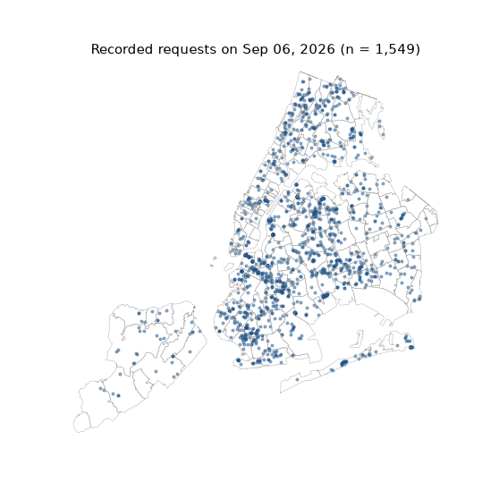

Geocoded illegal-parking request locations by day against NYC ZCTA boundaries, September 6–12, 2026.

```python
map_points = request_points.to_crs("EPSG:2263")
map_boundaries = zcta_polygons.to_crs("EPSG:2263")
frame_dates = pd.date_range(
    parking["created_at"].min().normalize(),
    parking["created_at"].max().normalize(),
    freq="D",
)
min_x, min_y, max_x, max_y = map_boundaries.total_bounds
x_margin = (max_x - min_x) * 0.03
y_margin = (max_y - min_y) * 0.03

fig, ax = plt.subplots(figsize=(6.2, 6.2))
map_boundaries.boundary.plot(ax=ax, color="#999999", linewidth=0.3)
points = ax.scatter([], [], color="#225588", s=5, alpha=0.45)
frame_title = ax.set_title("")
ax.set_xlim(min_x - x_margin, max_x + x_margin)
ax.set_ylim(min_y - y_margin, max_y + y_margin)
ax.set_aspect("equal")
ax.set_axis_off()

def update_map(frame):
    date = frame_dates[frame]
    current = map_points.loc[
        map_points["created_at"].dt.normalize().eq(date)
    ]
    coordinates = np.column_stack((current.geometry.x, current.geometry.y))
    points.set_offsets(coordinates)
    frame_title.set_text(
        f"Recorded requests on {date:%b %d, %Y} (n = {len(current):,})"
    )
    return points, frame_title

map_animation = FuncAnimation(
    fig, update_map, frames=range(len(frame_dates)),
    interval=700, repeat=False,
)
map_gif = display_gif(
    map_animation,
    alt_text="An animated map shows daily points for geocoded illegal-parking requests over fixed outlines of New York City ZCTAs.",
    caption="Geocoded illegal-parking request locations by day against NYC ZCTA boundaries, September 6–12, 2026.",
)
plt.close(fig)
map_gif
```

The two animations make different comparisons: the bars emphasize accumulation, while the map shows the daily distribution of recorded locations. Neither should be read as evidence of a stable pattern from one week. The animation can direct attention to dates or places for follow-up; the static hourly, daily, and area summaries elsewhere in this chapter provide more reliable comparisons across groups. Students should state the frame unit, whether values accumulate or reset, the fixed scales, and the data excluded from each animation.

The same visual discipline applies when the course moves from description to modeling. A predicted-versus-observed plot can show where a model systematically overpredicts or underpredicts an outcome; a residual plot can reveal structure that an average error measure conceals. Neither plot is interpretable until the target, prediction unit, eligible observations, and evaluation data are defined. A plot of training residuals, for example, answers a different question from one based on held-out predictions. Chapter 9 develops that framework. The present chapter establishes the complementary visual procedure: preserve units, expose variation relevant to the question, label transformations and exclusions, and check whether the displayed evidence supports the claim in the title and interpretation (Munzner, 2014; Yu & Barter, 2024). These requirements make a figure useful across exploration, communication, and model diagnosis. They also give students a way to revise a first attempt: identify the inference the reader is invited to make, then inspect each data and design decision that supports it.

## Exercises

The exercises move from a specified comparison to a self-directed project question. Submit source code, rendered figures, captions, and brief written interpretations. For each figure, identify the row unit, eligible records, variables, visual mappings, source, observation period, and a limit on the claim. For a new NYC Open Data source, record its dataset identifier, access date, relevant data-dictionary definitions, and any filtering or aggregation. An attractive plot alone does not satisfy these requirements.

**8.1** Use the results of Exercise 7.1 to visualize how the proportion of requests taking at least two hours to close varies across the four six-hour creation intervals and problem details. Use the same threshold and eligible records; focus on translating the EDA comparison into a figure rather than rebuilding its contingency tables.

1. Use the three most frequent problem details identified in the EDA exercise. Construct one plot with color and one with facets. Explain which comparison becomes easier in each, and show the number of eligible requests behind the proportions.
2. Build a `facet_grid()` with problem detail in rows and borough in columns. Explain what fixed vertical scales allow readers to compare. Then use free vertical scales and explain how the interpretation changes.
3. State the denominator for each plotted proportion and how requests with missing closure time are handled. Explain one way unequal group sizes affect interpretation and identify a limitation that remains.

**8.2** Create and repair two misleading plots from the illegal-parking data. Use two *different* mistakes from the table in Section 8.4; at least one must concern data selection, aggregation, or interpretation rather than only styling.

1. For each pair, show the same underlying records and explain the inference the flawed version invites.
2. Revise the mapping, scale, summary, label, or caption as needed. State which information the repair reveals and which limitation it cannot fix.
3. Cite one of the chapter’s empirical or methodological references that supports each revision. Explain how its finding applies to your example.

**8.3** Investigate the geographic pattern of illegal-parking requests using both the supplied point coordinates and the ZCTA boundary file.

1. Make a point map with a defensible display rule for overlap. Report the number of requests without coordinates and explain what a point means.
2. Compare the provider’s five-digit ZIP-label match with a point-in-polygon spatial join. Report unmatched and multiply matched points before choosing an area-assignment rule.
3. Map one count and one normalized quantity. Define the denominator and explain why neither map alone measures the risk of illegal parking. Add an interactive version only if it helps a specified reader task.

**8.4** Prepare a small visualization proposal for a midterm project. Select a dataset beyond the distributed 311 extract, such as NYC Open Data’s Motor Vehicle Collisions or Parks Inspection Program records (NYC Open Data, 2026a, 2026b).

1. State one question the data can address and one tempting question it cannot address without further information. Inspect the data dictionary before choosing a figure.
2. Make an exploratory graphic and revise it for an identified audience. Choose the chart form and tool yourself, and justify their visual mappings, aggregation, and any interaction.
3. Write a caption and alternative text. Record one analytical decision that changed after inspecting the first plot, and explain how you checked that decision against the source data.

**8.5** After Chapter 9, use held-out predictions from a model with a continuous outcome to make a predicted-versus-observed plot and a residual plot. Define the target, prediction unit, and held-out observations. Identify one pattern that an average performance measure conceals, and explain what the plots cannot establish about future observations.

## References

Armstrong, Z., & Wattenberg, M. (2014). Visualizing statistical mix effects and Simpson’s paradox. *IEEE Transactions on Visualization and Computer Graphics*, *20*(12), 2132–2141. https://doi.org/10.1109/TVCG.2014.2346297

Bateman, S., Mandryk, R. L., Gutwin, C., Genest, A., McDine, D., & Brooks, C. (2010). Useful junk? The effects of visual embellishment on comprehension and memorability of charts. *Proceedings of the SIGCHI Conference on Human Factors in Computing Systems*, 2573–2582. https://doi.org/10.1145/1753326.1753716

CARTO. (2026). *Get your CARTO basemaps API key*. https://www.carto.com/basemaps/apikey/

Cleveland, W. S., & McGill, R. (1984). Graphical perception: Theory, experimentation, and application to the development of graphical methods. *Journal of the American Statistical Association*, *79*(387), 531–554. https://doi.org/10.1080/01621459.1984.10478080

Correll, M., Bertini, E., & Franconeri, S. (2020). Truncating the Y-axis: Threat or menace? *Proceedings of the 2020 CHI Conference on Human Factors in Computing Systems*. https://doi.org/10.1145/3313831.3376222

Correll, M., & Gleicher, M. (2014). Error bars considered harmful: Exploring alternate encodings for mean and error. *IEEE Transactions on Visualization and Computer Graphics*, *20*(12), 2142–2151. https://doi.org/10.1109/TVCG.2014.2346298

Crameri, F., Shephard, G. E., & Heron, P. J. (2020). The misuse of colour in science communication. *Nature Communications*, *11*, 5444. https://doi.org/10.1038/s41467-020-19160-7

GeoPandas Developers. (2026a). *Interactive mapping*. https://geopandas.org/en/stable/docs/user_guide/interactive_mapping.html

GeoPandas Developers. (2026b). *Projections*. https://geopandas.org/en/stable/docs/user_guide/projections.html

Google for Developers. (2026a). *Data layer*. https://developers.google.com/maps/documentation/javascript/datalayer

Google for Developers. (2026b). *Maps JavaScript API usage and billing*. https://developers.google.com/maps/documentation/javascript/usage-and-billing

Google for Developers. (2026c). *Set up the maps JavaScript API*. https://developers.google.com/maps/documentation/javascript/get-api-key

Harrower, M., & Brewer, C. A. (2003). ColorBrewer.org: An online tool for selecting colour schemes for maps. *The Cartographic Journal*, *40*(1), 27–37. https://doi.org/10.1179/000870403235002042

Heer, J., & Bostock, M. (2010). Crowdsourcing graphical perception: Using mechanical turk to assess visualization design. *Proceedings of the SIGCHI Conference on Human Factors in Computing Systems*, 203–212. https://doi.org/10.1145/1753326.1753357

Lo, L. Y.-H., Gupta, A., Shigyo, K., Wu, A., Bertini, E., & Qu, H. (2022). Misinformed by visualization: What do we learn from misinformative visualizations? *Computer Graphics Forum*, *41*(3), 515–525. https://doi.org/10.1111/cgf.14559

Mackinlay, J. D. (1986). Automating the design of graphical presentations of relational information. *ACM Transactions on Graphics*, *5*(2), 110–141. https://doi.org/10.1145/22949.22950

Matplotlib Developers. (2026). *FuncAnimation*. https://matplotlib.org/stable/api/_as_gen/matplotlib.animation.FuncAnimation.html

Munzner, T. (2014). *Visualization analysis and design*. A K Peters/CRC Press. https://doi.org/10.1201/b17511

NYC Open Data. (n.d.). *311 service requests from 2020 to present*. Retrieved September 27, 2026, from https://data.cityofnewyork.us/d/erm2-nwe9

NYC Open Data. (2026a). *Motor vehicle collisions - crashes*. https://data.cityofnewyork.us/Public-Safety/Motor-Vehicle-Collisions-Crashes/h9gi-nx95

NYC Open Data. (2026b). *Parks inspection program - inspections*. https://data.cityofnewyork.us/dataset/Parks-Inspection-Program-Inspections/yg3y-7juh

NYC Open Data. (2026c). *ZIP code tabulation areas*. https://data.cityofnewyork.us/City-Government/ZIP-Code-Tabulation-Areas/35j5-n34v

Openshaw, S. (1984). *The modifiable areal unit problem*. Geo Books. http://qmrg.org.uk/files/2008/11/38-maup-openshaw.pdf

Pandey, A. V., Rall, K., Satterthwaite, M. L., Nov, O., & Bertini, E. (2015). How deceptive are deceptive visualizations? An empirical analysis of common distortion techniques. *Proceedings of the 2015 CHI Conference on Human Factors in Computing Systems*, 1469–1478. https://doi.org/10.1145/2702123.2702608

Plotnine Developers. (2026). *Facets (subplots)*. https://plotnine.org/guide/facets.html

Robinson, W. S. (1950). Ecological correlations and the behavior of individuals. *American Sociological Review*, *15*(3), 351–357. https://doi.org/10.2307/2087176

Tufte, E. R. (2001). *The visual display of quantitative information* (2nd ed.). Graphics Press.

U.S. Census Bureau. (2023). *ZIP code tabulation areas (ZCTAs)*. https://www.census.gov/programs-surveys/geography/guidance/geo-areas/zctas.html

Wainer, H. (1984). How to display data badly. *The American Statistician*, *38*(2), 137–147. https://doi.org/10.1080/00031305.1984.10483186

Weissgerber, T. L., Milic, N. M., Winham, S. J., & Garovic, V. D. (2015). Beyond bar and line graphs: Time for a new data presentation paradigm. *PLOS Biology*, *13*(4), e1002128. https://doi.org/10.1371/journal.pbio.1002128

Wickham, H. (2010). A layered grammar of graphics. *Journal of Computational and Graphical Statistics*, *19*(1), 3–28. https://doi.org/10.1198/jcgs.2009.07098

Wilke, C. O. (2019). *Fundamentals of data visualization: A primer on making informative and compelling figures*. O’Reilly Media. https://clauswilke.com/dataviz/

Wilkinson, L. (2005). *The grammar of graphics* (2nd ed.). Springer. https://doi.org/10.1007/0-387-28695-0

Yu, B., & Barter, R. L. (2024). *Veridical data science: The practice of responsible data analysis and decision making*. The MIT Press. https://vdsbook.com/